# Reproducible Research: Peer Assessment 1

### 1.0 Loading the data

```r
if(!file.exists("./activityMonitoringData"))
  {dir.create("./activityMonitoringData")}
fileUrl <- "https://d396qusza40orc.cloudfront.net/repdata%2Fdata%2Factivity.zip"
download.file(fileUrl,destfile="./activityMonitoringData.zip",method="libcurl")
unzip(zipfile="./activityMonitoringData.zip",exdir="./data")
pathFile <- file.path("./data" , "activity.csv")
activityData <- read.table(pathFile, sep = ",", header = T)
str(activityData)
```

```
## 'data.frame':    17568 obs. of  3 variables:
##  $ steps   : int  NA NA NA NA NA NA NA NA NA NA ...
##  $ date    : Factor w/ 61 levels "2012-10-01","2012-10-02",..: 1 1 1 1 1 1 1 1 1 1 ...
##  $ interval: int  0 5 10 15 20 25 30 35 40 45 ...
```

### 2.0 Evaluating the mean total number of steps taken per day

The missing data is ignored

```r
Data1 <- aggregate(steps ~ date, activityData, mean)
str(Data1)
```

```
## 'data.frame':    53 obs. of  2 variables:
##  $ date : Factor w/ 61 levels "2012-10-01","2012-10-02",..: 2 3 4 5 6 7 9 10 11 12 ...
##  $ steps: num  0.438 39.417 42.069 46.16 53.542 ...
```

### 3.0 A histogram of mean total number of steps taken each day

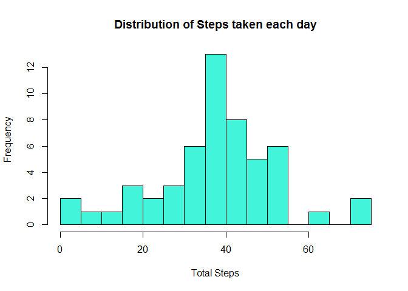

```r
steps <- as.numeric(Data1$steps)
hist(steps, breaks=15, main = "Distribution of Steps taken each day", col = "#42f4d9", xlab = "Total Steps")
```

### 4.0 Mean steps per day

Calculating the mean steps per day ignoring the missing values

```r
Mean_Steps <- round(mean(Data1$steps), 0)
Mean_Steps
```

```
## [1] 37
```

Calculating the median steps per day ignoring the missing values

```r
Median_Steps <- round(median(Data1$steps), 0)
Median_Steps
```

```
## [1] 37
```

### 5.0 What is the average daily activity pattern?

```r
daily_Average_Steps <- aggregate(steps ~ interval, activityData, mean)
str(daily_Average_Steps)
```

```
## 'data.frame':    288 obs. of  2 variables:
##  $ interval: int  0 5 10 15 20 25 30 35 40 45 ...
##  $ steps   : num  1.717 0.3396 0.1321 0.1509 0.0755 ...
```

Making a time series plot of the 5-minute interval and the average number of steps taken, averaged across all days (y-axis)

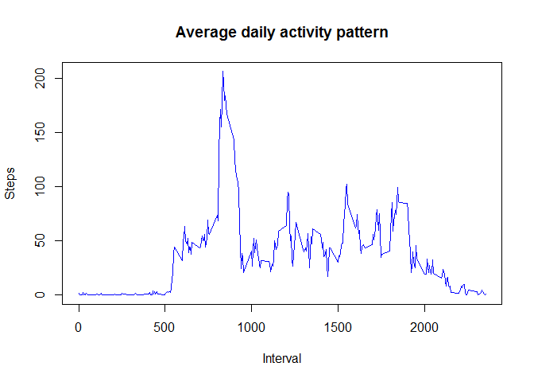

```r
plot(daily_Average_Steps$interval, daily_Average_Steps$steps,  type = "l", main = "Average daily activity pattern", xlab = "Interval", ylab = "Steps", col="blue")
```

### 6.0 The 5-minute interval containing the maximum number of steps.

```r
highestNumberOfSteps <- max(daily_Average_Steps$steps)
subset(daily_Average_Steps, daily_Average_Steps$steps == highestNumberOfSteps)$interval
```

```
## [1] 835
```

### 7.0 Imputing missing values

The presence of missing days (coded as `NA`) may introduce bias into some calculations or summaries of the data.

```r
nrow( activityData[ activityData$steps=="NA", ])
```

```
## [1] 2304
```

Replacing the NAs with the mean

```r
activityData$steps[which(is.na(activityData$steps))] <- mean(na.omit(activityData$steps))
head(activityData)
```

```
##     steps       date interval
## 1 37.3826 2012-10-01        0
## 2 37.3826 2012-10-01        5
## 3 37.3826 2012-10-01       10
## 4 37.3826 2012-10-01       15
## 5 37.3826 2012-10-01       20
## 6 37.3826 2012-10-01       25
```

### 8.0 Evaluating the mean total number of steps without NA`s

Average daily total number of steps

```r
Data2 <- aggregate(steps ~ date, activityData, sum)
Data1$steps <- as.numeric(Data1$steps)
str(Data2)
```

```
## 'data.frame':    61 obs. of  2 variables:
##  $ date : Factor w/ 61 levels "2012-10-01","2012-10-02",..: 1 2 3 4 5 6 7 8 9 10 ...
##  $ steps: num  10766 126 11352 12116 13294 ...
```

```r
summary(Data2)
```

```
##          date        steps
##  2012-10-01: 1   Min.   :   41
##  2012-10-02: 1   1st Qu.: 9819
##  2012-10-03: 1   Median :10766
##  2012-10-04: 1   Mean   :10766
##  2012-10-05: 1   3rd Qu.:12811
##  2012-10-06: 1   Max.   :21194
##  (Other)   :55
```

### 9.0 Making a histogram of mean total number of steps taken each day

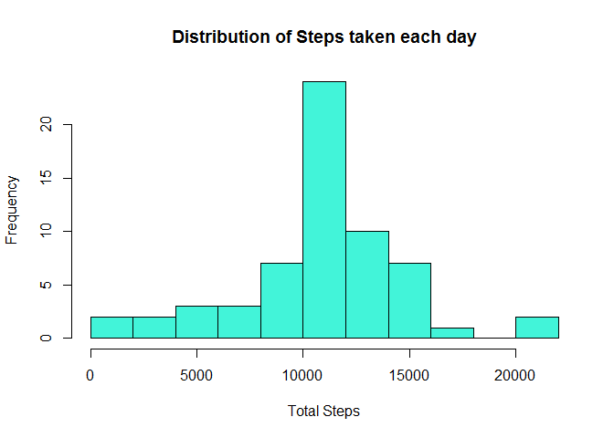

```r
steps <- as.numeric(Data2$steps)
hist(steps, breaks=15, main = "Distribution of Steps taken each day", col = "#42f4d9", xlab = "Total Steps")
```